# MWRDAnalysis

UIC

The analysis of the given datasets which are as following is done on R.

##### 1. Service Desk

##### 2. Outage Notification

##### 3. Change Request Form

We have included the code within the documentation within the document to let the technical users leverage it.First we will be analyzing the Service Desk dataset.

```r
library(readxl)
ServiceDeskModified <- read_excel("D:/UIC/3rd Semester/Capstone/datafrommwrd/ServiceDeskModified.xlsx")
Sdm<-ServiceDeskModified
```

Function to know which column has categorical values so that it can be converted to factor variables.Have to use nrow , length does not work for a tibble

```r
differentValues<-data.frame()
for(i in 1:ncol(Sdm)){
  differentValues[i,1]<-nrow(unique(Sdm[,i]))
}
colsFactor<-Sdm[!seq(from = 1,to = ncol(Sdm),by = 1) %in% which(differentValues>20)]
Sdm[,c(2:4,6,7,8)]<-lapply(colsFactor,FUN =factor)
```

Adding few columns after change in requirements

```r
library(readxl)
ServiceDesk_Data <- read_excel("D:/UIC/MyResearch/Mwrd/mwrdAnalysis/ServiceDesk Data.xlsx",
    col_types = c("numeric", "numeric", "text",
        "text", "text", "text", "text", "text",
        "text", "text", "date", "date", "text",
        "text", "numeric", "numeric", "numeric",
        "text", "text", "text", "text", "text",
        "text", "text", "text", "text", "text",
        "text", "text", "text", "text", "text"))
ServiceDesk_Data<-ServiceDesk_Data[,c(4,11,12,18)]
Sdm<-cbind(Sdm,ServiceDesk_Data)
```

Let’s take a look at the dataset and the variables after a bit of modification

Service Desk

| ID | STATE | PRIORITY | CATEGORY | SUBCATEGORY | IS_SERVICE_REQUEST | SITE | DEPARTMENT | DESCRIPTION_NO_HTML | CREATED_AT | UPDATED_AT | CREATED_BY |
| --- | --- | --- | --- | --- | --- | --- | --- | --- | --- | --- | --- |
| 18622955 | Assigned | Medium | IT Audio/Visual/Conference | In-District Video Conference Setup | TRUE | Stickney Water Reclamation Plant | Monitoring & Research | The IT Department is happy to assist with your upcoming event. Services offered are: -Audio/Video Conference Bridge -Recoding A/V Live streaming (Board Room Only) -Projector -Setup and Breakdown of La… | 2017-10-04 13:22:47 | 2017-10-04 14:05:43 | OKAL, JOHN |
| 18622953 | Assigned | None | Core-Applications | MWRD Website Requests | TRUE | MOB | General Administration | The ITD department will process website update requests submitted through the Service Desk. Please provide the following information to initiate the process. Name of QA Approver(s) - Please add as a C… | 2017-10-04 13:22:43 | 2017-10-04 13:23:21 | LARKIN, DIANE |
| 18622457 | New | Medium | ServiceDesk - Triage | NA | FALSE | Northside/Obrien Plant | Monitoring & Research | The chip key for the pool vehicle 1704 is not functioning. Gets an error message like this “key not in the file system” Raju Antony Environmental Specialist MWRDGC\|Industrial Waste Division O’Brien W… | 2017-10-04 13:09:20 | 2017-10-04 13:09:20 | ANTONY, RAJU |
| 18622304 | Resolved | Medium | ServiceDesk - Triage | Re-Entered as a Service Request | FALSE | Stickney Water Reclamation Plant | Monitoring & Research | See Below. Marie Biron Adminstrative Specialist Environmental Monitoring and Research Division Monitoring and Research Department 6001 W Pershing Road Cicero, IL 60804 PH:708.588.4264 Email: marie.bir… | 2017-10-04 13:05:15 | 2017-10-04 13:23:58 | BIRON, MARIE |
| 18622045 | Resolved | Medium | Security Modification | Network Account Password Reset | TRUE | Stickney Water Reclamation Plant | Maintenance & Operations | The IT Service desk can assist you with unlocking and/or resetting your Network, SAP, ReadSoft, Portal or voicemail password. Please provide your Employees ID, network login username and a contact tel… | 2017-10-04 12:59:56 | 2017-10-04 13:02:33 | OKAL, JOHN |

## Exploratory Analysis

How many tickets have been resolved

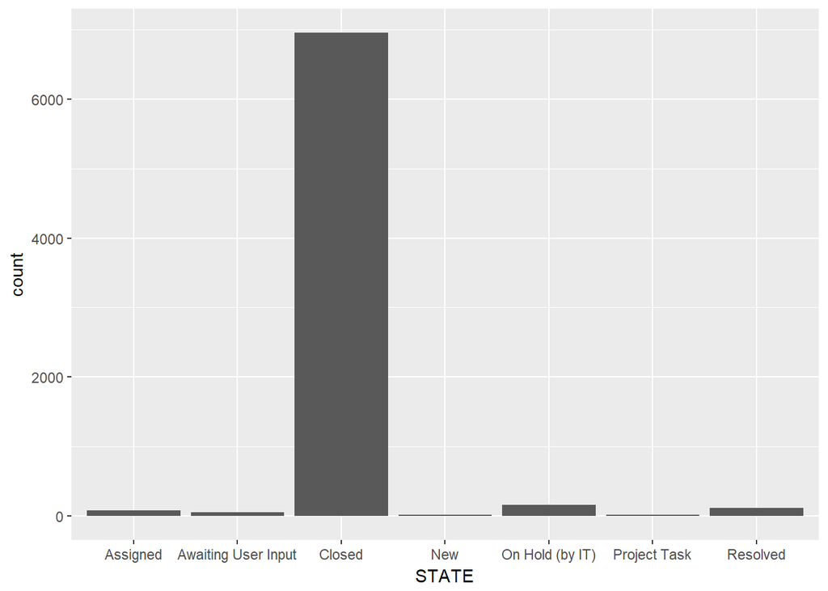

From the plot we see that majority of them are closed ? We don’t have the date embedded in the data source file else we would have calculated

What category are most of my tickets ?

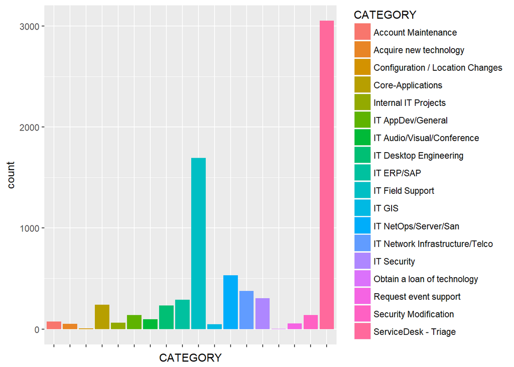

Which Plant are raising the most requests for tickets ?

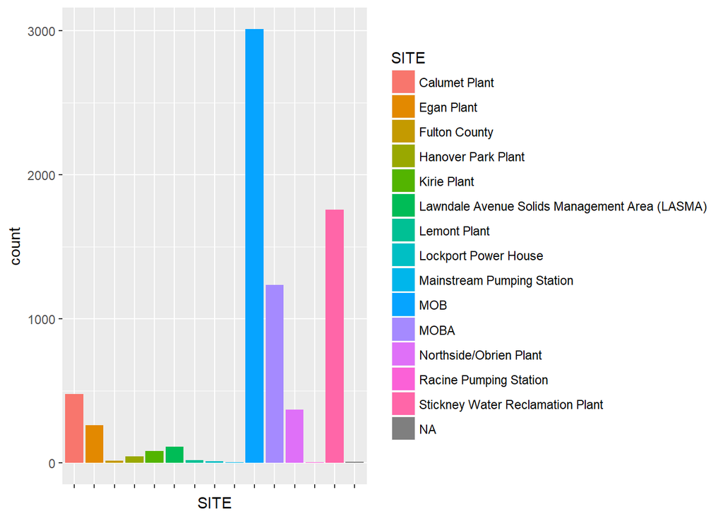

Which department is raising most of the tickets ?

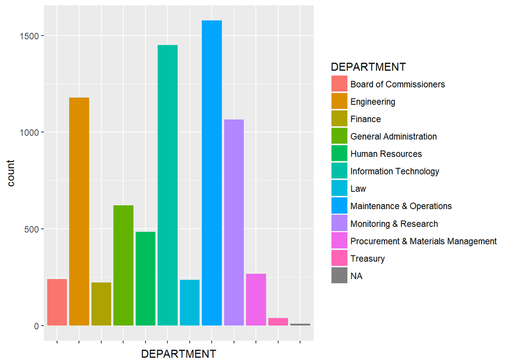

We want to see who has created most of the tickets

```r
library(knitr)
Sdm$CREATED_BY<-as.factor(Sdm$CREATED_BY)
Most_Tickets_Created<-as.data.frame(head(sort(table(Sdm$CREATED_BY),decreasing = T),n=50))
kable(Most_Tickets_Created,caption = "Most_Tickets_Created")
```

Most_Tickets_Created

| Var1 | Freq |
| --- | --- |
| UKPONG, IMEH | 2116 |
| OKAL, JOHN | 1899 |
| JONES, RON | 837 |
| WRIGHT, SEMAJ | 232 |
| SMITH, CHRISTOPHER | 219 |
| LARKIN, DIANE | 202 |
| KODY, JOSEPH | 137 |
| YOUNG, KEVIN | 104 |
| REICHLING, JOHN | 95 |
| RODGERS, GERALD | 85 |
| JEFFERSON, DEJIAH | 82 |
| NWOKO, MARCEL | 58 |
| ROBERTS, LASHUN | 55 |
| CHAPPELL, YVONNE | 53 |
| MCENERY, THOMAS | 52 |
| FOY, CASSANDRA | 48 |
| MALONE, LARRY | 48 |
| SANCHEZ, VICTOR | 41 |
| JOHNSTON, SAM | 40 |
| MIKA, KEVIN | 31 |
| SIA, JOEL | 28 |
| KELLY, SEAN | 26 |
| DIZON, ARTURO | 25 |
| KANE, PATRICK | 25 |
| ECKLUND, SCOTT | 24 |
| RAHMAN, ABDUR | 23 |
| LOPATKA, MARK | 20 |
| MCCAGUE, RAYMOND | 18 |
| THOMPSON, RONALD | 17 |
| KAZMIERCZAK, KIM | 16 |
| MONDLOCK, ROGER | 16 |
| KHALID, ARSHAD | 15 |
| MUSCARELLO, THOMAS | 15 |
| WOJKOVICH, RICHARD | 15 |
| CARTER, HUGH | 13 |
| DOMINA, JOSHUA | 12 |
| EBERHART, ERIC | 11 |
| JACKSON, CHENTILE | 11 |
| WARREN, ETHAN | 11 |
| COLVIN, CYNTHIA | 10 |
| SMITH, ROGER | 10 |
| CHENG, ERVIN | 9 |
| SENESE, SERGIO | 9 |
| BONNER, ROXANNE | 8 |
| KONKAPAKA, SHARMA | 8 |
| SCHRAMM, MICHAEL | 8 |
| SONTA, BIRUTE | 8 |
| LABAN, AHMAD | 7 |
| PATLOGAN, ILA | 7 |
| WRIGHT, SHARON | 7 |

### Going a bit deeper into Exploratory analysis

Since our concerned departments are MOB and MOBA we are filtering data and then analyzing by department

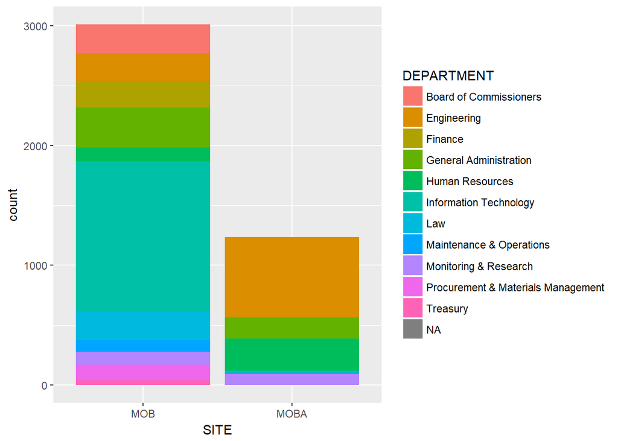

```r
library(dplyr)
g4<-ggplot(data=(Sdm %>% filter(SITE %in% c("MOBA","MOB"))),aes(x=SITE,Y=DEPARTMENT))+
geom_bar(aes(x=SITE,fill=DEPARTMENT))

plot(g4)
```

**We see that most of the tickets raised are for Information Technology department in MOB and Engineering department in MOBA**

Let’s us see the priority of tickets in these two departments

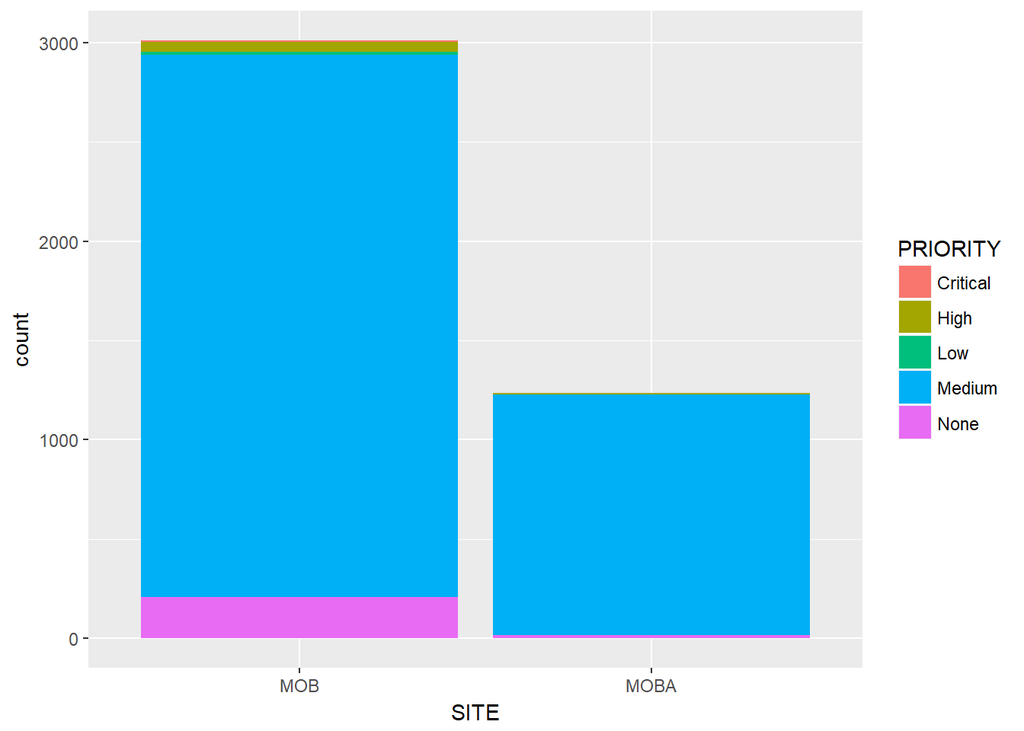

```r
library(dplyr)
g4<-ggplot(data=(Sdm %>% filter(SITE %in% c("MOBA","MOB"))),aes(x=SITE,Y=PRIORITY))+
geom_bar(aes(x=SITE,fill=PRIORITY))

plot(g4)
```

**In both the departments tickets generated are of priority medium**

# Text Mining on the Description column

The approach is to to count the frequency of words that matter and remove those words out which are of common English and to remove those words which have zero information content ( from our perspective and client’s perspective )

Step 1 : Collapse all the descriptions into a paragraph Step 2 : Replace punctuations such as ,_:/ etc. Step 3 : Repace all the digits Step 3 : Replace single letter words Step 4 : Replace stopwords words such as a,and,of,the Step 5 : Delete additional words in a retrospective manner Step 6 : Make a textbag of words and after that create a frequency table

```r
##### Text Mining
text<-paste(Sdm$DESCRIPTION_NO_HTML,collapse = "")
write(text,"description.txt")
#punctuation replacement
text2<-gsub(pattern = "\\W",replacement = " ",text)
# digits replacement
text2<-gsub(pattern="\\d",replacement = "",text2)
text2<-gsub(pattern = "\\b[A-z]\\b{1}",replacement = "",text2)

library(tm)
# words removed with no information
text2<-removeWords(text2,stopwords())
library(stringr)
textbagWithoutCleaning<-str_split(text2,pattern="\\s+")
textbagWithoutCleaning<-unlist(textbagWithoutCleaning)
write.csv(head(sort(table(textbagWithoutCleaning),decreasing = T),n=300),file = "withoutcleaning.csv")
text2<-removeWords(text2,words=c("mwrd","Please","org","User","can","will","The","Thanks","user","From","Thank","To","reached","get","MWRD","see","th","like","This","Can","able","If","We","For","know","use","It","Hi","need","needed","needs","please","Help","My","now","trying","used","help","also","via"))
textbag<-str_split(text2,pattern="\\s+")
textbag<-unlist(textbag)
write.csv(head(sort(table(textbag),decreasing = T),n=300),file = "withcleaning.csv")
```

We will be creating a wordcloud as well as the frequencies of the word

**Creating a wordcloud**

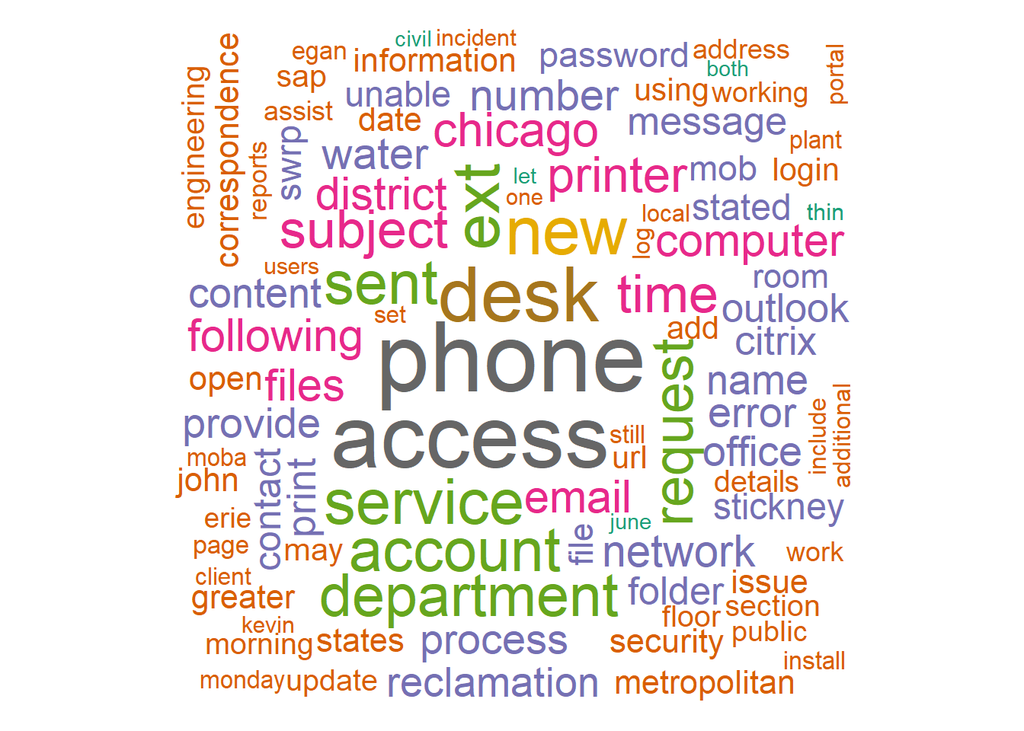

```r
library(RColorBrewer)
library(wordcloud)
wordcloud(textbag,min.freq = 250,random.order = FALSE,colors =brewer.pal(8,"Dark2"),scale = c(4,0.5))
```

# Change Request Form

```r
library(readr)
Change_Request_Form<- read_csv("D:/UIC/3rd Semester/Capstone/datafrommwrd/Change Request Form Modified.csv")
```

### A Look at the Dataset

```r
kable(Change_Request_Form[1:5,],caption = "Change Request Form")
```

Change Request Form

| Status Indicator | Create Date | Maintenance Date | Responsible IT Area | Impact Category | Purpose Group | Emergency / Time Senstive |
| --- | --- | --- | --- | --- | --- | --- |
| NA | 10/5/2017 13:52 | 10/19/2017 | GIS | Minor | Preventive | NA |
| NA | 10/5/2017 11:42 | 10/19/2017 | Network Infrastructure | Major | Enhancement | NA |
| NA | 10/5/2017 11:38 | 10/18/2017 | Network Infrastructure | Major | Enhancement | NA |
| NA | 9/29/2017 10:36 | 10/11/2017 | Desktop Engineering (Citrix, SCCM) | Minor | Enhancement | NA |
| Follow-up (See Status Notes) | 9/27/2017 10:53 | 9/28/2017 | Desktop Engineering (Citrix, SCCM) | Minor | Fix / Patch | NA |

We see that our data frame has dates.But while importing from a CSV it is read as a character.To convert this column for meaningful purposes we will convert it regex in R.Now we will extract the time and add a column for time

```r
library("dplyr")
Change_Request_Form<-mutate(.data = Change_Request_Form,CreatedTime=gsub(pattern ="[0-9]{1,}/[0-9]{1,}/[0-9]{1,}" ,replacement ="" ,x = Change_Request_Form$`Create Date`))
```

We will pull the dates now.

```r
library("dplyr")
Change_Request_Form<-mutate(.data = Change_Request_Form,CreatedDate=gsub(pattern ="([0-9]{1,}/[0-9]{1,}/[0-9]{1,}).*" ,replacement ="\\1" ,x = Change_Request_Form$`Create Date`))
```

We need to delete the existing column for Date time and create proper formatting for Date and Time

```r
Change_Request_Form$CreatedDate<-as.Date(x = Change_Request_Form$CreatedDate,format = "%m/%d/%Y")
Change_Request_Form$CreatedTime<-trimws(Change_Request_Form$CreatedTime,which="left")
library("lubridate")
Change_Request_Form$CreatedTime<-hm(Change_Request_Form$CreatedTime)
Change_Request_Form$`Maintenance Date`<-as.Date(x = Change_Request_Form$`Maintenance Date`,format = "%m/%d/%Y")
Change_Request_Form<-Change_Request_Form[,c(1,8,9,3,4,5,6,7)]
```

**We will be creating a difference in dates which is the most important parameter. This will explain us in how many days the response team responded**

```r
Change_Request_Form<-mutate(.data = Change_Request_Form,DiffDays= difftime(time1 = Change_Request_Form$`Maintenance Date`,time2 = Change_Request_Form$CreatedDate,units = "days"))
```

We can get the descriptive statistics for DiffDays

```r
summary(as.numeric(Change_Request_Form$DiffDays))
```

```
##    Min. 1st Qu.  Median    Mean 3rd Qu.    Max.
##   -5.00    1.00    9.00   16.14   17.00  262.00
```

```r
DiffDays<-as.data.frame(as.numeric(Change_Request_Form$DiffDays))
```

We can see that Min=-5 and Max=262.The mean is 16 days and Median is 9 days. We would like to know how many tickets are solved within a given time duration. We will be creating bins for different tickets

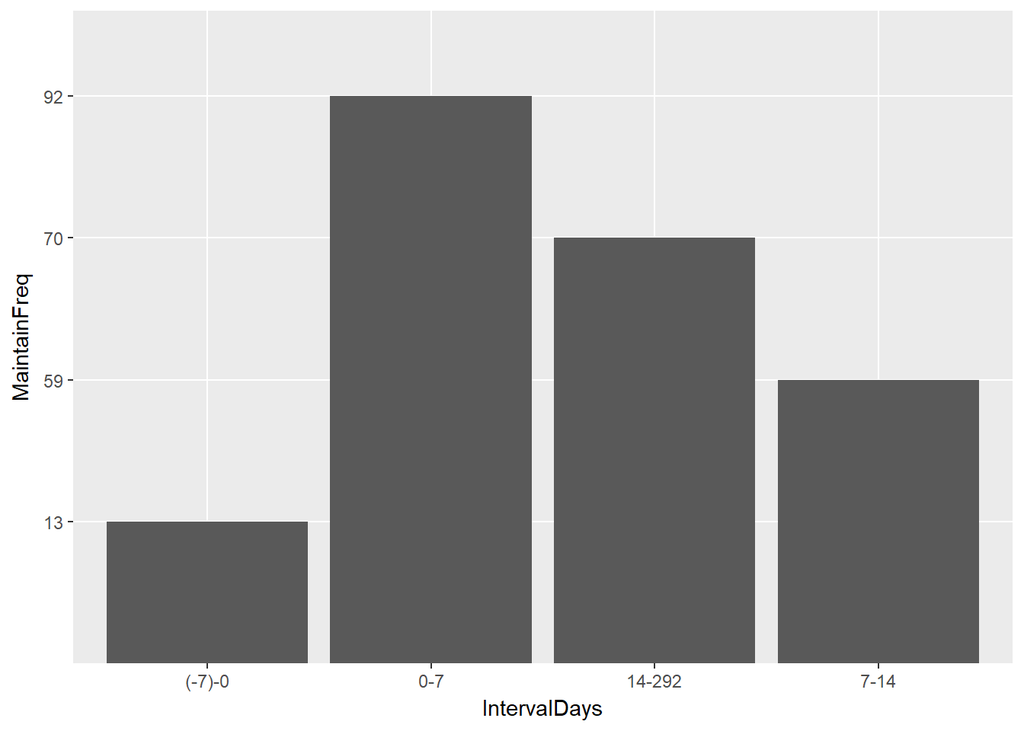

```r
D<-data.frame(IntervalDays=c("(-7)-0","0-7","7-14","14-292"),MaintainFreq=c("13","92","59","70"))
View(D)
g5<-ggplot(data=D)+
geom_col(aes(x=IntervalDays,y=MaintainFreq))
plot(g5)
```

```r
kable(D[1:4,],caption = "Maintainenance")
```

Maintainenance

| IntervalDays | MaintainFreq |
| --- | --- |
| (-7)-0 | 13 |
| 0-7 | 92 |
| 7-14 | 59 |
| 14-292 | 70 |

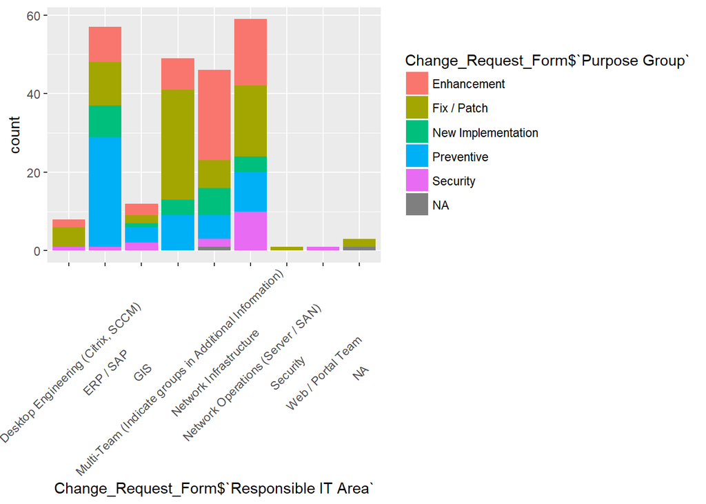

```r
g6<-ggplot(data = Change_Request_Form)+
geom_bar(aes(x=Change_Request_Form$`Responsible IT Area`,fill=Change_Request_Form$`Purpose Group`))+
theme(axis.text.x =element_text(angle = 45, vjust = 0.5 , hjust = 0.5))

plot(g6)
```

# Analysis of Outage Notification Form

```r
library(readr)
Onm<- read_csv("D:/UIC/MyResearch/Mwrd/mwrdAnalysis/Outage Notification Modified.csv",
    col_types = cols(`Create Date` = col_datetime(format = "%m/%d/%Y %H:%M"),
        `Outage End Date` = col_date(format = "%m/%d/%Y"),
        `Outage Start Date` = col_date(format = "%m/%d/%Y")))
```

A look at the dataset

```r
kable(Onm[1:5,],caption = "Outage Notification Form")
```

Outage Notification Form

[output not shown]

How long it takes to close the ticket ?

```r
library("knitr")
library("dplyr")
Onm<-mutate(.data = Onm,OnmDiffDays=difftime(time1 = Onm$`Outage End Date`,time2 = Onm$`Outage Start Date`,units = "days"))
summary(as.numeric(Onm$OnmDiffDays))
```

Min. 1st Qu. Median Mean 3rd Qu. Max. NA’s 0.0000 0.0000 0.0000 0.7651 1.0000 30.0000 2

```r
setNames(as.data.frame(table(as.numeric(Onm$OnmDiffDays))),c("Outage Lasted","Frequency"))
```

Outage Lasted Frequency 1 0 121 2 1 25 3 2 7 4 3 3 5 4 4 6 5 2 7 6 1 8 7 1 9 10 1 10 30 1

Which IT area the tickets belong to ?

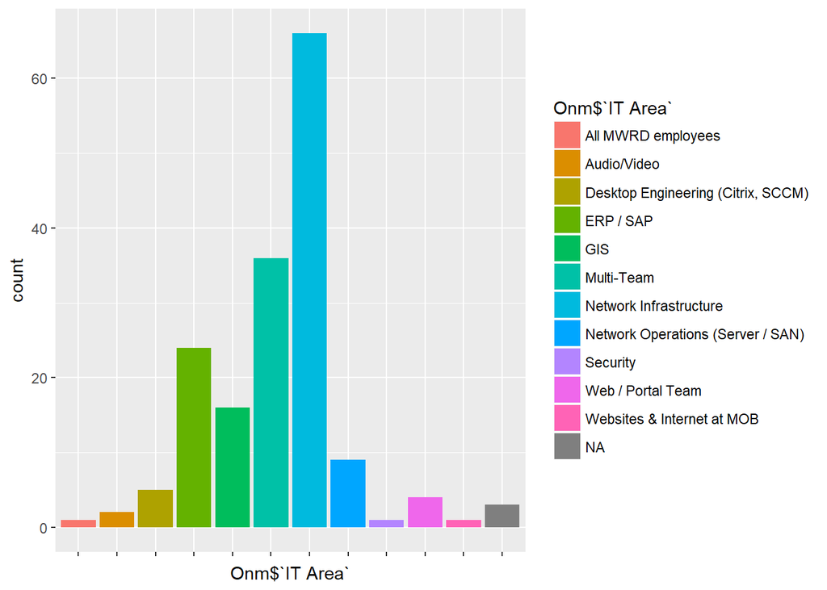

```r
g7<-ggplot(data = Onm)+
geom_bar(aes(Onm$`IT Area`,fill=Onm$`IT Area`))+
theme(axis.text.x = element_blank())
plot(g7)
```